# Sai_Prasad

```python
!mkdir -p ~/.kaggle
```

```python
from google.colab import files
files.upload()
```

```
Saving kaggle.json to kaggle.json
```

```
{'kaggle.json': b'{"username":"saiprasadb2","key":"06e7dc3b5f8f65409a8ad5e2a767f12f"}'}
```

```python
!cp kaggle.json ~/.kaggle/
```

```python
!chmod 600 ~/.kaggle/kaggle.json
```

```python
!ls ~/.kaggle
```

```
kaggle.json
```

```python
!kaggle competitions download -c dogs-vs-cats
```

```
Downloading dogs-vs-cats.zip to /content
100% 811M/812M [00:38<00:00, 20.5MB/s]
100% 812M/812M [00:38<00:00, 22.3MB/s]
```

```python
!unzip -qq dogs-vs-cats.zip
```

```python
!unzip -qq train.zip
```

```python
!ls train
```

[output not shown]

[output cut: 3517 more lines]

[output not shown]

Question 1: Consider the Cats & Dogs example. Start initially with a training sample of 1000, a validation sample of 500, and a test sample of 500 (like in the text). Use any technique to reduce overfitting and improve performance in developing a network that you train from scratch. What performance did you achieve?

copying images to the test, validation, and training directories

```python
import os, shutil, pathlib

original_dataset_dir = pathlib.Path("train")
base_dataset_dir = pathlib.Path("cats_vs_dogs_small")

def make_subset(subset_name, start_index, end_index):
    for category in ("cat", "dog"):
        dir = base_dataset_dir / subset_name / category
        os.makedirs(dir, exist_ok=True)
        fnames = [f"{category}.{i}.jpg" for i in range(start_index, end_index)]
        for fname in fnames:
            shutil.copyfile(src=original_dataset_dir / fname,
                            dst=dir / fname)


make_subset("train", start_index=667, end_index=1667)
make_subset("validation", start_index=1668, end_index=2168)
make_subset("test", start_index=2169, end_index=2669)
```

Interpreting images with "image_dataset_from_directory"

```python
from tensorflow.keras.utils import image_dataset_from_directory

train = image_dataset_from_directory(
    base_dataset_dir / "train",
    image_size=(180, 180),
    batch_size=32)

validation = image_dataset_from_directory(
    base_dataset_dir / "validation",
    image_size=(180, 180),
    batch_size=32)

test = image_dataset_from_directory(
    base_dataset_dir / "test",
    image_size=(180, 180),
    batch_size=32)
```

```
Found 2000 files belonging to 2 classes.
Found 1000 files belonging to 2 classes.
Found 1000 files belonging to 2 classes.
```

Create a dataset instance with 1000 random samples, each with a vector size of 16 using a NumPy array.

```python
import numpy as np
import tensorflow as tf
random_num = np.random.normal(size=(1000, 16))
data = tf.data.Dataset.from_tensor_slices(random_num)
```

```python
for i, element in enumerate(data):
    print(element.shape)
    if i >= 2:
        break
```

```
(16,)
(16,)
(16,)
```

```python
for i, element in enumerate(data):
    print(element.shape)
    if i >= 2:
        break
```

```
(16,)
(16,)
(16,)
```

```python
reshapedata = data.map(lambda x: tf.reshape(x, (4, 4)))
for i, element in enumerate(reshapedata):
    print(element.shape)
    if i >= 2:
        break
```

```
(4, 4)
(4, 4)
(4, 4)
```

Developing the model

Creating a tiny network for categorizing dogs versus cats

```python
for data_batch, labels_batch in train:
    print("data batch shape:", data_batch.shape)
    print("labels batch shape:", labels_batch.shape)
    break
```

```
data batch shape: (32, 180, 180, 3)
labels batch shape: (32,)
```

```python
from tensorflow import keras
from tensorflow.keras import layers

input = keras.Input(shape=(180, 180, 3))
a = layers.Rescaling(1./255)(input)
a = layers.Conv2D(filters=32, kernel_size=3, activation="relu")(a)
a = layers.MaxPooling2D(pool_size=2)(a)
a = layers.Conv2D(filters=64, kernel_size=3, activation="relu")(a)
a = layers.MaxPooling2D(pool_size=2)(a)
a = layers.Conv2D(filters=128, kernel_size=3, activation="relu")(a)
a = layers.MaxPooling2D(pool_size=2)(a)
a = layers.Conv2D(filters=256, kernel_size=3, activation="relu")(a)
a = layers.MaxPooling2D(pool_size=2)(a)
a = layers.Conv2D(filters=256, kernel_size=3, activation="relu")(a)
a = layers.Flatten()(a)
a = layers.Dropout(0.5)(a)
output1 = layers.Dense(1, activation="sigmoid")(a)
model1 = keras.Model(inputs=input, outputs=output1)
```

preparing model for training

```python
model1.compile(loss="binary_crossentropy",
              optimizer="adam",
              metrics=["accuracy"])
```

The model is constructed at first, then it is then trained using the training dataset. We use the validation dataset to verify the model's performance at the end of each phase. I'm utilizing a GPU to reduce the processing length of each phase.

```python
model1.summary()
```

```
Model: "functional"
```

```
┏━━━━━━━━━━━━━━━━━━━━━━━━━━━━━━━━━━━━━━┳━━━━━━━━━━━━━━━━━━━━━━━━━━━━━┳━━━━━━━━━━━━━━━━━┓
┃ Layer (type)                         ┃ Output Shape                ┃         Param # ┃
┡━━━━━━━━━━━━━━━━━━━━━━━━━━━━━━━━━━━━━━╇━━━━━━━━━━━━━━━━━━━━━━━━━━━━━╇━━━━━━━━━━━━━━━━━┩
│ input_layer (InputLayer)             │ (None, 180, 180, 3)         │               0 │
├──────────────────────────────────────┼─────────────────────────────┼─────────────────┤
│ rescaling (Rescaling)                │ (None, 180, 180, 3)         │               0 │
├──────────────────────────────────────┼─────────────────────────────┼─────────────────┤
│ conv2d (Conv2D)                      │ (None, 178, 178, 32)        │             896 │
├──────────────────────────────────────┼─────────────────────────────┼─────────────────┤
│ max_pooling2d (MaxPooling2D)         │ (None, 89, 89, 32)          │               0 │
├──────────────────────────────────────┼─────────────────────────────┼─────────────────┤
│ conv2d_1 (Conv2D)                    │ (None, 87, 87, 64)          │          18,496 │
├──────────────────────────────────────┼─────────────────────────────┼─────────────────┤
│ max_pooling2d_1 (MaxPooling2D)       │ (None, 43, 43, 64)          │               0 │
├──────────────────────────────────────┼─────────────────────────────┼─────────────────┤
│ conv2d_2 (Conv2D)                    │ (None, 41, 41, 128)         │          73,856 │
├──────────────────────────────────────┼─────────────────────────────┼─────────────────┤
│ max_pooling2d_2 (MaxPooling2D)       │ (None, 20, 20, 128)         │               0 │
├──────────────────────────────────────┼─────────────────────────────┼─────────────────┤
│ conv2d_3 (Conv2D)                    │ (None, 18, 18, 256)         │         295,168 │
├──────────────────────────────────────┼─────────────────────────────┼─────────────────┤
│ max_pooling2d_3 (MaxPooling2D)       │ (None, 9, 9, 256)           │               0 │
├──────────────────────────────────────┼─────────────────────────────┼─────────────────┤
│ conv2d_4 (Conv2D)                    │ (None, 7, 7, 256)           │         590,080 │
├──────────────────────────────────────┼─────────────────────────────┼─────────────────┤
│ flatten (Flatten)                    │ (None, 12544)               │               0 │
├──────────────────────────────────────┼─────────────────────────────┼─────────────────┤
│ dropout (Dropout)                    │ (None, 12544)               │               0 │
├──────────────────────────────────────┼─────────────────────────────┼─────────────────┤
│ dense (Dense)                        │ (None, 1)                   │          12,545 │
└──────────────────────────────────────┴─────────────────────────────┴─────────────────┘
```

```
 Total params: 991,041 (3.78 MB)
```

```
 Trainable params: 991,041 (3.78 MB)
```

```
 Non-trainable params: 0 (0.00 B)
```

Model fitting follows using the dataset.

```python
from keras.callbacks import ModelCheckpoint, EarlyStopping

callback1 = [
    keras.callbacks.ModelCheckpoint(
        filepath="convnet_from_scratch.keras",
        save_best_only=True,
        monitor="val_loss")
]
history1 = model1.fit(
    train,
    epochs=10,
    validation_data=validation,
    callbacks=callback1)
```

```
63/63 ━━━━━━━━━━━━━━━━━━━━ 21s 189ms/step - accuracy: 0.5149 - loss: 0.6978 - val_accuracy: 0.5870 - val_loss: 0.6799
63/63 ━━━━━━━━━━━━━━━━━━━━ 4s 70ms/step - accuracy: 0.5575 - loss: 0.6870 - val_accuracy: 0.5140 - val_loss: 0.7842
63/63 ━━━━━━━━━━━━━━━━━━━━ 7s 100ms/step - accuracy: 0.5996 - loss: 0.6620 - val_accuracy: 0.5700 - val_loss: 0.6816
63/63 ━━━━━━━━━━━━━━━━━━━━ 8s 58ms/step - accuracy: 0.6203 - loss: 0.6492 - val_accuracy: 0.5210 - val_loss: 0.7108
63/63 ━━━━━━━━━━━━━━━━━━━━ 3s 54ms/step - accuracy: 0.6279 - loss: 0.6397 - val_accuracy: 0.6360 - val_loss: 0.6456
63/63 ━━━━━━━━━━━━━━━━━━━━ 8s 102ms/step - accuracy: 0.6870 - loss: 0.5894 - val_accuracy: 0.6500 - val_loss: 0.6484
63/63 ━━━━━━━━━━━━━━━━━━━━ 7s 52ms/step - accuracy: 0.7140 - loss: 0.5635 - val_accuracy: 0.6580 - val_loss: 0.6463
63/63 ━━━━━━━━━━━━━━━━━━━━ 8s 96ms/step - accuracy: 0.7226 - loss: 0.5401 - val_accuracy: 0.6680 - val_loss: 0.6301
63/63 ━━━━━━━━━━━━━━━━━━━━ 4s 58ms/step - accuracy: 0.7563 - loss: 0.4915 - val_accuracy: 0.6880 - val_loss: 0.6237
63/63 ━━━━━━━━━━━━━━━━━━━━ 5s 55ms/step - accuracy: 0.8117 - loss: 0.4139 - val_accuracy: 0.6970 - val_loss: 0.6130
```

In order to improve visualization and understanding, training curves for accuracy and loss were created.

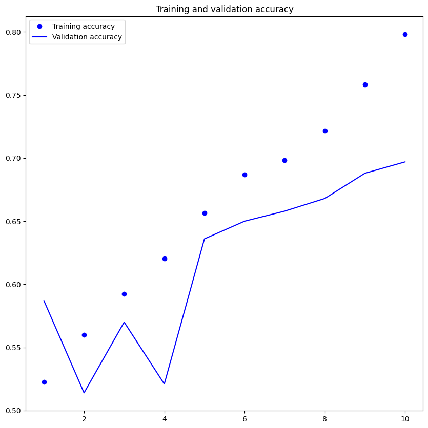

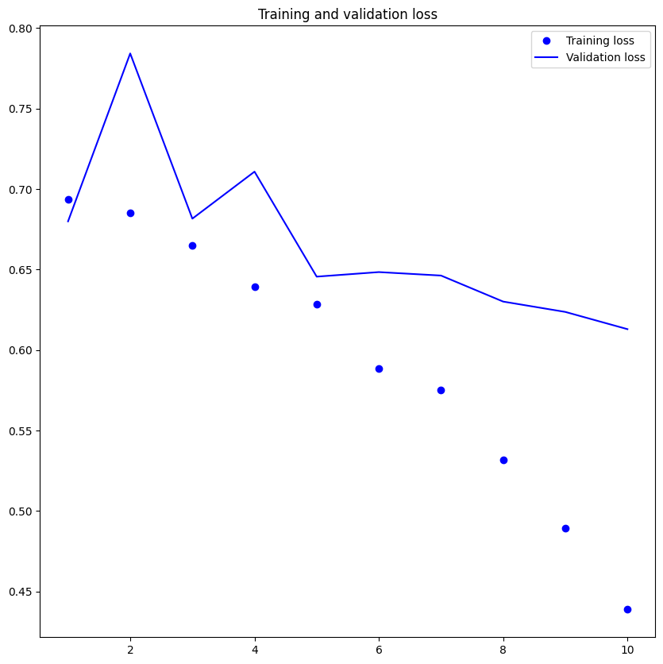

```python
import matplotlib.pyplot as plt

plt.figure(figsize=(10, 10))
accuracy1 = history1.history["accuracy"]
val_accuracy1 = history1.history["val_accuracy"]
loss1 = history1.history["loss"]
val_loss1 = history1.history["val_loss"]
epochs = range(1, len(accuracy1) + 1)
plt.plot(epochs, accuracy1, "bo", label="Training accuracy")
plt.plot(epochs, val_accuracy1, "b", label="Validation accuracy")
plt.title("Training and validation accuracy")
plt.legend()
plt.figure()
plt.figure(figsize=(10, 10))
plt.plot(epochs, loss1, "bo", label="Training loss")
plt.plot(epochs, val_loss1, "b", label="Validation loss")
plt.title("Training and validation loss")
plt.legend()
plt.show()
```

```python
testacc1 = keras.models.load_model("convnet_from_scratch.keras")
test_loss, test_acc = testacc1.evaluate(test)
print(f"Test accuracy: {test_acc:.3f}")
```

```
32/32 ━━━━━━━━━━━━━━━━━━━━ 2s 39ms/step - accuracy: 0.7136 - loss: 0.5573
Test accuracy: 0.698
```

Question 2: Increase your training sample size. You may pick any amount. Keep the validation and test samples the same as above. Optimize your network (again training from scratch). What performance did you achieve?

Using data augmentation

Define a data augmentation stage to add to an image model

```python
import os, shutil, pathlib

shutil.rmtree("./cats_vs_dogs_small_Q2", ignore_errors=True)

# Define the original directory and the new base directory
original_dataset_dir = pathlib.Path("train")
base_dataset_dir = pathlib.Path("cats_vs_dogs_small_Q2")

# Function to create subsets
def make_subset(subset_name, start_index, end_index):
    for category in ("cat", "dog"):
        dir = base_dataset_dir / subset_name / category
        os.makedirs(dir, exist_ok=True)  # Create directory, if it doesn't exist
        fnames = [f"{category}.{i}.jpg" for i in range(start_index, end_index)]
        for fname in fnames:
            shutil.copyfile(src=original_dataset_dir / fname,
                            dst=dir / fname)

# Creating subsets for training, validation, and testing
make_subset("train", start_index=667, end_index=2167)  # 1500 samples
make_subset("validation", start_index=2168, end_index=2668)  # 500 samples
make_subset("test", start_index=2669, end_index=3168)  # 500 samples
```

```python
augmentation = keras.Sequential(
    [
        layers.RandomFlip("horizontal"),
        layers.RandomRotation(0.1),
        layers.RandomZoom(0.2),
    ]
)
```

showing the training augmented pictures

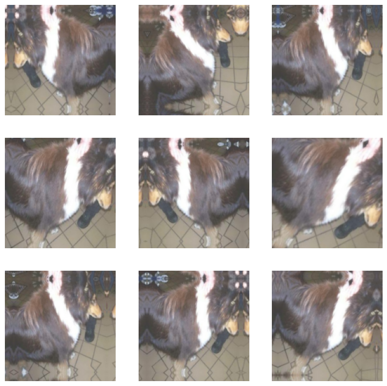

```python
plt.figure(figsize=(10, 10))
for images, _ in train.take(1):
    for i in range(9):
        augmented_pics = augmentation(images)
        ax = plt.subplot(3, 3, i + 1)
        plt.imshow(augmented_pics[0].numpy().astype("uint8"))
        plt.axis("off")
```

Developing a new convolutional neural network that includes picture augmentation and dropout

```python
input2 = keras.Input(shape=(180, 180, 3))
b = augmentation(input2)
b = layers.Rescaling(1./255)(b)
b = layers.Conv2D(filters=32, kernel_size=3, activation="relu")(b)
b = layers.MaxPooling2D(pool_size=2)(b)
b = layers.Conv2D(filters=64, kernel_size=3, activation="relu")(b)
b = layers.MaxPooling2D(pool_size=2)(b)
b = layers.Conv2D(filters=128, kernel_size=3, activation="relu")(b)
b = layers.MaxPooling2D(pool_size=2)(b)
b = layers.Conv2D(filters=256, kernel_size=3, activation="relu")(b)
b = layers.MaxPooling2D(pool_size=2)(b)
b = layers.Conv2D(filters=256, kernel_size=3, activation="relu")(b)
b = layers.Flatten()(b)
b = layers.Dropout(0.5)(b)
output2 = layers.Dense(1, activation="sigmoid")(b)
model2 = keras.Model(inputs=input2, outputs=output2)

model2.compile(loss="binary_crossentropy",
              optimizer="adam",
              metrics=["accuracy"])
```

```python
from keras.callbacks import ModelCheckpoint, EarlyStopping
callback2 = [
    keras.callbacks.ModelCheckpoint(
        filepath="convnet_from_scratch_with_augmentation.keras",
        save_best_only=True,
        monitor="val_loss")
]
history2 = model2.fit(
    train,
    epochs=30,
    validation_data=validation,
    callbacks=callback2)
```

```
63/63 ━━━━━━━━━━━━━━━━━━━━ 10s 86ms/step - accuracy: 0.4963 - loss: 0.7007 - val_accuracy: 0.5000 - val_loss: 0.6938
63/63 ━━━━━━━━━━━━━━━━━━━━ 6s 58ms/step - accuracy: 0.5113 - loss: 0.6937 - val_accuracy: 0.5000 - val_loss: 0.6929
63/63 ━━━━━━━━━━━━━━━━━━━━ 5s 57ms/step - accuracy: 0.5065 - loss: 0.6940 - val_accuracy: 0.5000 - val_loss: 0.6938
63/63 ━━━━━━━━━━━━━━━━━━━━ 5s 82ms/step - accuracy: 0.4958 - loss: 0.6935 - val_accuracy: 0.5000 - val_loss: 0.6910
63/63 ━━━━━━━━━━━━━━━━━━━━ 5s 74ms/step - accuracy: 0.4959 - loss: 0.6893 - val_accuracy: 0.5000 - val_loss: 0.6883
63/63 ━━━━━━━━━━━━━━━━━━━━ 4s 63ms/step - accuracy: 0.5407 - loss: 0.6831 - val_accuracy: 0.5480 - val_loss: 0.6860
63/63 ━━━━━━━━━━━━━━━━━━━━ 4s 60ms/step - accuracy: 0.5749 - loss: 0.6759 - val_accuracy: 0.5990 - val_loss: 0.6753
63/63 ━━━━━━━━━━━━━━━━━━━━ 7s 107ms/step - accuracy: 0.5888 - loss: 0.6685 - val_accuracy: 0.6100 - val_loss: 0.6609
63/63 ━━━━━━━━━━━━━━━━━━━━ 7s 57ms/step - accuracy: 0.6212 - loss: 0.6509 - val_accuracy: 0.6190 - val_loss: 0.6908
63/63 ━━━━━━━━━━━━━━━━━━━━ 5s 72ms/step - accuracy: 0.6482 - loss: 0.6491 - val_accuracy: 0.6640 - val_loss: 0.6243
63/63 ━━━━━━━━━━━━━━━━━━━━ 6s 81ms/step - accuracy: 0.6685 - loss: 0.6221 - val_accuracy: 0.6820 - val_loss: 0.6172
63/63 ━━━━━━━━━━━━━━━━━━━━ 4s 57ms/step - accuracy: 0.6815 - loss: 0.6068 - val_accuracy: 0.6930 - val_loss: 0.6136
63/63 ━━━━━━━━━━━━━━━━━━━━ 7s 83ms/step - accuracy: 0.6941 - loss: 0.6102 - val_accuracy: 0.6600 - val_loss: 0.6185
63/63 ━━━━━━━━━━━━━━━━━━━━ 5s 71ms/step - accuracy: 0.6698 - loss: 0.6093 - val_accuracy: 0.6830 - val_loss: 0.6184
63/63 ━━━━━━━━━━━━━━━━━━━━ 4s 57ms/step - accuracy: 0.6879 - loss: 0.5848 - val_accuracy: 0.7110 - val_loss: 0.5827
63/63 ━━━━━━━━━━━━━━━━━━━━ 6s 67ms/step - accuracy: 0.7109 - loss: 0.5586 - val_accuracy: 0.7040 - val_loss: 0.5797
63/63 ━━━━━━━━━━━━━━━━━━━━ 6s 76ms/step - accuracy: 0.6673 - loss: 0.6037 - val_accuracy: 0.6930 - val_loss: 0.6145
63/63 ━━━━━━━━━━━━━━━━━━━━ 4s 57ms/step - accuracy: 0.7459 - loss: 0.5348 - val_accuracy: 0.7340 - val_loss: 0.5514
63/63 ━━━━━━━━━━━━━━━━━━━━ 6s 64ms/step - accuracy: 0.7539 - loss: 0.5353 - val_accuracy: 0.6710 - val_loss: 0.6357
63/63 ━━━━━━━━━━━━━━━━━━━━ 6s 75ms/step - accuracy: 0.7158 - loss: 0.5367 - val_accuracy: 0.7240 - val_loss: 0.5634
63/63 ━━━━━━━━━━━━━━━━━━━━ 4s 63ms/step - accuracy: 0.7440 - loss: 0.5186 - val_accuracy: 0.7360 - val_loss: 0.5433
63/63 ━━━━━━━━━━━━━━━━━━━━ 4s 64ms/step - accuracy: 0.7573 - loss: 0.5038 - val_accuracy: 0.7420 - val_loss: 0.5358
63/63 ━━━━━━━━━━━━━━━━━━━━ 6s 83ms/step - accuracy: 0.7494 - loss: 0.5034 - val_accuracy: 0.7410 - val_loss: 0.5401
63/63 ━━━━━━━━━━━━━━━━━━━━ 9s 62ms/step - accuracy: 0.7702 - loss: 0.4894 - val_accuracy: 0.7370 - val_loss: 0.5582
63/63 ━━━━━━━━━━━━━━━━━━━━ 5s 87ms/step - accuracy: 0.7796 - loss: 0.4828 - val_accuracy: 0.7470 - val_loss: 0.5306
63/63 ━━━━━━━━━━━━━━━━━━━━ 5s 72ms/step - accuracy: 0.7650 - loss: 0.4798 - val_accuracy: 0.7510 - val_loss: 0.5059
63/63 ━━━━━━━━━━━━━━━━━━━━ 4s 56ms/step - accuracy: 0.7913 - loss: 0.4548 - val_accuracy: 0.7680 - val_loss: 0.5203
63/63 ━━━━━━━━━━━━━━━━━━━━ 8s 97ms/step - accuracy: 0.7740 - loss: 0.4545 - val_accuracy: 0.6920 - val_loss: 0.6089
63/63 ━━━━━━━━━━━━━━━━━━━━ 8s 58ms/step - accuracy: 0.7703 - loss: 0.4906 - val_accuracy: 0.7720 - val_loss: 0.5027
63/63 ━━━━━━━━━━━━━━━━━━━━ 6s 79ms/step - accuracy: 0.8026 - loss: 0.4333 - val_accuracy: 0.7840 - val_loss: 0.4771
```

Model evaluated based on test set

```python
testacc2 = keras.models.load_model(
    "convnet_from_scratch_with_augmentation.keras")
test_loss, test_acc = testacc2.evaluate(test)
print(f"Test accuracy: {test_acc:.3f}")
```

```
32/32 ━━━━━━━━━━━━━━━━━━━━ 2s 56ms/step - accuracy: 0.8113 - loss: 0.4309
Test accuracy: 0.788
```

Question 3: Now change your training sample so that you achieve better performance than those from Steps 1 and 2. This sample size may be larger, or smaller than those in the previous steps. The objective is to find the ideal training sample size to get best prediction results.

Training accuracy increases with 1000 training samples.

```python
original_dir = pathlib.Path("train")
new_base_dir = pathlib.Path("cats_vs_dogs_small_Q3")

def make_subset(subset_name, start_index, end_index):
    for category in ("cat", "dog"):
        dir = new_base_dir / subset_name / category
        os.makedirs(dir)
        fnames = [f"{category}.{i}.jpg" for i in range(start_index, end_index)]
        for fname in fnames:
            shutil.copyfile(src=original_dir / fname,
                            dst=dir / fname)
#Creating training, Test and validation sets.
#Training has 2000 samples, test has 500 samples and validation has 500 samples.
make_subset("train", start_index=667, end_index=2667)
make_subset("validation", start_index=2668, end_index=3168)
make_subset("test", start_index=3169, end_index=3669)
```

```python
i3 = keras.Input(shape=(180, 180, 3))
c = augmentation(i3)
c = layers.Rescaling(1./255)(c)
c = layers.Conv2D(filters=32, kernel_size=3, activation="relu")(c)
c = layers.MaxPooling2D(pool_size=2)(c)
c = layers.Conv2D(filters=64, kernel_size=3, activation="relu")(c)
c = layers.MaxPooling2D(pool_size=2)(c)
c = layers.Conv2D(filters=128, kernel_size=3, activation="relu")(c)
c = layers.MaxPooling2D(pool_size=2)(c)
c = layers.Conv2D(filters=256, kernel_size=3, activation="relu")(c)
c = layers.MaxPooling2D(pool_size=2)(c)
c = layers.Conv2D(filters=256, kernel_size=3, activation="relu")(c)
c = layers.Flatten()(c)
c = layers.Dropout(0.5)(c)
out3 = layers.Dense(1, activation="sigmoid")(c)
mod3 = keras.Model(inputs=i3, outputs=out3)

mod3.compile(loss="binary_crossentropy",
              optimizer="adam",
              metrics=["accuracy"])
```

```python
callback3 = [
    keras.callbacks.ModelCheckpoint(
        filepath="convnet_from_scratch_with_augmentation1.keras",
        save_best_only=True,
        monitor="val_loss")
]
hist3 = mod3.fit(
    train,
    epochs=50,
    validation_data=validation,
    callbacks=callback3)
```

```
63/63 ━━━━━━━━━━━━━━━━━━━━ 7s 69ms/step - accuracy: 0.5146 - loss: 0.6943 - val_accuracy: 0.5000 - val_loss: 0.6935
63/63 ━━━━━━━━━━━━━━━━━━━━ 4s 56ms/step - accuracy: 0.4925 - loss: 0.6935 - val_accuracy: 0.5000 - val_loss: 0.6941
63/63 ━━━━━━━━━━━━━━━━━━━━ 6s 73ms/step - accuracy: 0.4856 - loss: 0.6951 - val_accuracy: 0.5450 - val_loss: 0.6921
63/63 ━━━━━━━━━━━━━━━━━━━━ 6s 81ms/step - accuracy: 0.5441 - loss: 0.6905 - val_accuracy: 0.6240 - val_loss: 0.6737
63/63 ━━━━━━━━━━━━━━━━━━━━ 9s 69ms/step - accuracy: 0.5879 - loss: 0.6728 - val_accuracy: 0.5690 - val_loss: 0.6724
63/63 ━━━━━━━━━━━━━━━━━━━━ 5s 86ms/step - accuracy: 0.6033 - loss: 0.6674 - val_accuracy: 0.6160 - val_loss: 0.6569
63/63 ━━━━━━━━━━━━━━━━━━━━ 9s 63ms/step - accuracy: 0.6473 - loss: 0.6428 - val_accuracy: 0.6420 - val_loss: 0.6354
63/63 ━━━━━━━━━━━━━━━━━━━━ 7s 91ms/step - accuracy: 0.6369 - loss: 0.6443 - val_accuracy: 0.6470 - val_loss: 0.6414
63/63 ━━━━━━━━━━━━━━━━━━━━ 4s 58ms/step - accuracy: 0.6574 - loss: 0.6260 - val_accuracy: 0.6320 - val_loss: 0.6567
63/63 ━━━━━━━━━━━━━━━━━━━━ 5s 57ms/step - accuracy: 0.6725 - loss: 0.6190 - val_accuracy: 0.6820 - val_loss: 0.6207
63/63 ━━━━━━━━━━━━━━━━━━━━ 6s 91ms/step - accuracy: 0.6352 - loss: 0.6280 - val_accuracy: 0.6770 - val_loss: 0.6232
63/63 ━━━━━━━━━━━━━━━━━━━━ 8s 57ms/step - accuracy: 0.6597 - loss: 0.6232 - val_accuracy: 0.6750 - val_loss: 0.6297
63/63 ━━━━━━━━━━━━━━━━━━━━ 7s 84ms/step - accuracy: 0.6801 - loss: 0.6055 - val_accuracy: 0.6910 - val_loss: 0.5951
63/63 ━━━━━━━━━━━━━━━━━━━━ 5s 71ms/step - accuracy: 0.6972 - loss: 0.5964 - val_accuracy: 0.6860 - val_loss: 0.6056
63/63 ━━━━━━━━━━━━━━━━━━━━ 4s 57ms/step - accuracy: 0.6843 - loss: 0.5928 - val_accuracy: 0.6940 - val_loss: 0.5899
63/63 ━━━━━━━━━━━━━━━━━━━━ 4s 58ms/step - accuracy: 0.6906 - loss: 0.5880 - val_accuracy: 0.7030 - val_loss: 0.5890
63/63 ━━━━━━━━━━━━━━━━━━━━ 6s 101ms/step - accuracy: 0.7057 - loss: 0.5780 - val_accuracy: 0.6900 - val_loss: 0.6011
63/63 ━━━━━━━━━━━━━━━━━━━━ 4s 57ms/step - accuracy: 0.7188 - loss: 0.5561 - val_accuracy: 0.7050 - val_loss: 0.6024
63/63 ━━━━━━━━━━━━━━━━━━━━ 5s 57ms/step - accuracy: 0.7201 - loss: 0.5575 - val_accuracy: 0.7530 - val_loss: 0.5217
63/63 ━━━━━━━━━━━━━━━━━━━━ 8s 97ms/step - accuracy: 0.7297 - loss: 0.5329 - val_accuracy: 0.7460 - val_loss: 0.5394
63/63 ━━━━━━━━━━━━━━━━━━━━ 8s 57ms/step - accuracy: 0.7615 - loss: 0.5002 - val_accuracy: 0.7440 - val_loss: 0.5298
63/63 ━━━━━━━━━━━━━━━━━━━━ 7s 90ms/step - accuracy: 0.7288 - loss: 0.5284 - val_accuracy: 0.7710 - val_loss: 0.4929
63/63 ━━━━━━━━━━━━━━━━━━━━ 4s 67ms/step - accuracy: 0.7589 - loss: 0.4970 - val_accuracy: 0.7650 - val_loss: 0.4822
63/63 ━━━━━━━━━━━━━━━━━━━━ 5s 58ms/step - accuracy: 0.7574 - loss: 0.4849 - val_accuracy: 0.8000 - val_loss: 0.4610
63/63 ━━━━━━━━━━━━━━━━━━━━ 4s 66ms/step - accuracy: 0.7948 - loss: 0.4522 - val_accuracy: 0.7170 - val_loss: 0.5727
63/63 ━━━━━━━━━━━━━━━━━━━━ 6s 89ms/step - accuracy: 0.7822 - loss: 0.4696 - val_accuracy: 0.8040 - val_loss: 0.4793
63/63 ━━━━━━━━━━━━━━━━━━━━ 8s 56ms/step - accuracy: 0.7674 - loss: 0.4773 - val_accuracy: 0.7840 - val_loss: 0.4747
63/63 ━━━━━━━━━━━━━━━━━━━━ 5s 81ms/step - accuracy: 0.7816 - loss: 0.4527 - val_accuracy: 0.8130 - val_loss: 0.4192
63/63 ━━━━━━━━━━━━━━━━━━━━ 5s 78ms/step - accuracy: 0.8030 - loss: 0.4355 - val_accuracy: 0.8020 - val_loss: 0.4527
63/63 ━━━━━━━━━━━━━━━━━━━━ 4s 62ms/step - accuracy: 0.8280 - loss: 0.3950 - val_accuracy: 0.7990 - val_loss: 0.4597
63/63 ━━━━━━━━━━━━━━━━━━━━ 4s 56ms/step - accuracy: 0.8057 - loss: 0.4078 - val_accuracy: 0.7850 - val_loss: 0.4543
63/63 ━━━━━━━━━━━━━━━━━━━━ 7s 85ms/step - accuracy: 0.8109 - loss: 0.4171 - val_accuracy: 0.8040 - val_loss: 0.4315
63/63 ━━━━━━━━━━━━━━━━━━━━ 4s 62ms/step - accuracy: 0.8131 - loss: 0.3912 - val_accuracy: 0.7710 - val_loss: 0.4854
63/63 ━━━━━━━━━━━━━━━━━━━━ 5s 66ms/step - accuracy: 0.8147 - loss: 0.4111 - val_accuracy: 0.8260 - val_loss: 0.3952
63/63 ━━━━━━━━━━━━━━━━━━━━ 6s 91ms/step - accuracy: 0.8261 - loss: 0.3663 - val_accuracy: 0.8240 - val_loss: 0.4004
63/63 ━━━━━━━━━━━━━━━━━━━━ 8s 63ms/step - accuracy: 0.8309 - loss: 0.3656 - val_accuracy: 0.8280 - val_loss: 0.4076
63/63 ━━━━━━━━━━━━━━━━━━━━ 7s 91ms/step - accuracy: 0.8186 - loss: 0.3906 - val_accuracy: 0.8320 - val_loss: 0.3970
63/63 ━━━━━━━━━━━━━━━━━━━━ 8s 57ms/step - accuracy: 0.8269 - loss: 0.3491 - val_accuracy: 0.8270 - val_loss: 0.3864
63/63 ━━━━━━━━━━━━━━━━━━━━ 4s 67ms/step - accuracy: 0.8441 - loss: 0.3301 - val_accuracy: 0.8130 - val_loss: 0.4418
63/63 ━━━━━━━━━━━━━━━━━━━━ 6s 92ms/step - accuracy: 0.8584 - loss: 0.3167 - val_accuracy: 0.8120 - val_loss: 0.4391
63/63 ━━━━━━━━━━━━━━━━━━━━ 8s 56ms/step - accuracy: 0.8465 - loss: 0.3494 - val_accuracy: 0.8380 - val_loss: 0.4068
63/63 ━━━━━━━━━━━━━━━━━━━━ 6s 93ms/step - accuracy: 0.8501 - loss: 0.3354 - val_accuracy: 0.8150 - val_loss: 0.3950
63/63 ━━━━━━━━━━━━━━━━━━━━ 4s 65ms/step - accuracy: 0.8683 - loss: 0.3207 - val_accuracy: 0.8060 - val_loss: 0.4079
63/63 ━━━━━━━━━━━━━━━━━━━━ 5s 63ms/step - accuracy: 0.8422 - loss: 0.3461 - val_accuracy: 0.8280 - val_loss: 0.3943
63/63 ━━━━━━━━━━━━━━━━━━━━ 5s 83ms/step - accuracy: 0.8761 - loss: 0.2848 - val_accuracy: 0.8230 - val_loss: 0.3979
63/63 ━━━━━━━━━━━━━━━━━━━━ 5s 72ms/step - accuracy: 0.8426 - loss: 0.3498 - val_accuracy: 0.8180 - val_loss: 0.4197
63/63 ━━━━━━━━━━━━━━━━━━━━ 4s 61ms/step - accuracy: 0.8777 - loss: 0.2850 - val_accuracy: 0.8400 - val_loss: 0.3879
63/63 ━━━━━━━━━━━━━━━━━━━━ 6s 68ms/step - accuracy: 0.8764 - loss: 0.2738 - val_accuracy: 0.8610 - val_loss: 0.3641
63/63 ━━━━━━━━━━━━━━━━━━━━ 6s 77ms/step - accuracy: 0.8883 - loss: 0.2539 - val_accuracy: 0.8520 - val_loss: 0.3902
63/63 ━━━━━━━━━━━━━━━━━━━━ 3s 55ms/step - accuracy: 0.8806 - loss: 0.2940 - val_accuracy: 0.8470 - val_loss: 0.4192
```

```python
acc_test3 = keras.models.load_model(
    "convnet_from_scratch_with_augmentation1.keras")
test_loss, test_acc = acc_test3.evaluate(test)
print(f"Test accuracy: {test_acc:.3f}")
```

```
32/32 ━━━━━━━━━━━━━━━━━━━━ 1s 33ms/step - accuracy: 0.8279 - loss: 0.3947
Test accuracy: 0.830
```

Question 4: Repeat Steps 1-3, but now using a pretrained network. The sample sizes you use in Steps 2 and 3 for the pretrained network may be the same or different from those using the network where you trained from scratch. Again, use any and all optimization techniques to get best performance.

Instantiating the VGG16 convolutional base

```python
convolution_base = keras.applications.vgg16.VGG16(
    weights="imagenet",
    include_top=False,
    input_shape=(180, 180, 3))
```

```
Downloading data from https://storage.googleapis.com/tensorflow/keras-applications/vgg16/vgg16_weights_tf_dim_ordering_tf_kernels_notop.h5
58889256/58889256 ━━━━━━━━━━━━━━━━━━━━ 4s 0us/step
```

```python
convolution_base.summary()
```

```
Model: "vgg16"
```

```
┏━━━━━━━━━━━━━━━━━━━━━━━━━━━━━━━━━━━━━━┳━━━━━━━━━━━━━━━━━━━━━━━━━━━━━┳━━━━━━━━━━━━━━━━━┓
┃ Layer (type)                         ┃ Output Shape                ┃         Param # ┃
┡━━━━━━━━━━━━━━━━━━━━━━━━━━━━━━━━━━━━━━╇━━━━━━━━━━━━━━━━━━━━━━━━━━━━━╇━━━━━━━━━━━━━━━━━┩
│ input_layer_4 (InputLayer)           │ (None, 180, 180, 3)         │               0 │
├──────────────────────────────────────┼─────────────────────────────┼─────────────────┤
│ block1_conv1 (Conv2D)                │ (None, 180, 180, 64)        │           1,792 │
├──────────────────────────────────────┼─────────────────────────────┼─────────────────┤
│ block1_conv2 (Conv2D)                │ (None, 180, 180, 64)        │          36,928 │
├──────────────────────────────────────┼─────────────────────────────┼─────────────────┤
│ block1_pool (MaxPooling2D)           │ (None, 90, 90, 64)          │               0 │
├──────────────────────────────────────┼─────────────────────────────┼─────────────────┤
│ block2_conv1 (Conv2D)                │ (None, 90, 90, 128)         │          73,856 │
├──────────────────────────────────────┼─────────────────────────────┼─────────────────┤
│ block2_conv2 (Conv2D)                │ (None, 90, 90, 128)         │         147,584 │
├──────────────────────────────────────┼─────────────────────────────┼─────────────────┤
│ block2_pool (MaxPooling2D)           │ (None, 45, 45, 128)         │               0 │
├──────────────────────────────────────┼─────────────────────────────┼─────────────────┤
│ block3_conv1 (Conv2D)                │ (None, 45, 45, 256)         │         295,168 │
├──────────────────────────────────────┼─────────────────────────────┼─────────────────┤
│ block3_conv2 (Conv2D)                │ (None, 45, 45, 256)         │         590,080 │
├──────────────────────────────────────┼─────────────────────────────┼─────────────────┤
│ block3_conv3 (Conv2D)                │ (None, 45, 45, 256)         │         590,080 │
├──────────────────────────────────────┼─────────────────────────────┼─────────────────┤
│ block3_pool (MaxPooling2D)           │ (None, 22, 22, 256)         │               0 │
├──────────────────────────────────────┼─────────────────────────────┼─────────────────┤
│ block4_conv1 (Conv2D)                │ (None, 22, 22, 512)         │       1,180,160 │
├──────────────────────────────────────┼─────────────────────────────┼─────────────────┤
│ block4_conv2 (Conv2D)                │ (None, 22, 22, 512)         │       2,359,808 │
├──────────────────────────────────────┼─────────────────────────────┼─────────────────┤
│ block4_conv3 (Conv2D)                │ (None, 22, 22, 512)         │       2,359,808 │
├──────────────────────────────────────┼─────────────────────────────┼─────────────────┤
│ block4_pool (MaxPooling2D)           │ (None, 11, 11, 512)         │               0 │
├──────────────────────────────────────┼─────────────────────────────┼─────────────────┤
│ block5_conv1 (Conv2D)                │ (None, 11, 11, 512)         │       2,359,808 │
├──────────────────────────────────────┼─────────────────────────────┼─────────────────┤
│ block5_conv2 (Conv2D)                │ (None, 11, 11, 512)         │       2,359,808 │
├──────────────────────────────────────┼─────────────────────────────┼─────────────────┤
│ block5_conv3 (Conv2D)                │ (None, 11, 11, 512)         │       2,359,808 │
├──────────────────────────────────────┼─────────────────────────────┼─────────────────┤
│ block5_pool (MaxPooling2D)           │ (None, 5, 5, 512)           │               0 │
└──────────────────────────────────────┴─────────────────────────────┴─────────────────┘
```

```
 Total params: 14,714,688 (56.13 MB)
```

```
 Trainable params: 14,714,688 (56.13 MB)
```

```
 Non-trainable params: 0 (0.00 B)
```

using a pretrained model for feature extraction without data augmentation

obtaining the labels that correlate with the VGG16 characteristics

```python
import numpy as np

def get_features_and_labels(dataset):
    all_feature = []
    all_label = []
    for images, labels in dataset:
        preprocessed_images = keras.applications.vgg16.preprocess_input(images)
        features = convolution_base.predict(preprocessed_images)
        all_feature.append(features)
        all_label.append(labels)
    return np.concatenate(all_feature), np.concatenate(all_label)

train_features, train_labels =  get_features_and_labels(train)
val_features, val_labels =  get_features_and_labels(validation)
test_features, test_labels =  get_features_and_labels(test)
```

[output not shown]

[output cut: 72 more lines]

[output not shown]

```python
train_features.shape
```

```
(2000, 5, 5, 512)
```

```python
i6 = keras.Input(shape=(5, 5, 512))
d = layers.Flatten()(i6)
d = layers.Dense(256)(d)
d = layers.Dropout(0.5)(d)
out6 = layers.Dense(1, activation="sigmoid")(d)
m6 = keras.Model(i6, out6)
m6.compile(loss="binary_crossentropy",
              optimizer="rmsprop",
              metrics=["accuracy"])

callback6 = [
    keras.callbacks.ModelCheckpoint(
      filepath="feature_extraction.keras",
      save_best_only=True,
      monitor="val_loss")
]
hist6 = m6.fit(
    train_features, train_labels,
    epochs=20,
    validation_data=(val_features, val_labels),
    callbacks=callback6)
```

```
63/63 ━━━━━━━━━━━━━━━━━━━━ 4s 35ms/step - accuracy: 0.8548 - loss: 25.5397 - val_accuracy: 0.9800 - val_loss: 2.1867
63/63 ━━━━━━━━━━━━━━━━━━━━ 0s 3ms/step - accuracy: 0.9806 - loss: 1.9341 - val_accuracy: 0.9760 - val_loss: 3.4263
63/63 ━━━━━━━━━━━━━━━━━━━━ 0s 4ms/step - accuracy: 0.9870 - loss: 1.3219 - val_accuracy: 0.9780 - val_loss: 3.7143
63/63 ━━━━━━━━━━━━━━━━━━━━ 0s 4ms/step - accuracy: 0.9903 - loss: 1.4673 - val_accuracy: 0.9770 - val_loss: 3.1021
63/63 ━━━━━━━━━━━━━━━━━━━━ 0s 4ms/step - accuracy: 0.9941 - loss: 0.4276 - val_accuracy: 0.9770 - val_loss: 4.0674
63/63 ━━━━━━━━━━━━━━━━━━━━ 0s 3ms/step - accuracy: 0.9945 - loss: 0.9553 - val_accuracy: 0.9770 - val_loss: 4.0695
63/63 ━━━━━━━━━━━━━━━━━━━━ 0s 3ms/step - accuracy: 0.9966 - loss: 0.1576 - val_accuracy: 0.9790 - val_loss: 3.8644
63/63 ━━━━━━━━━━━━━━━━━━━━ 0s 4ms/step - accuracy: 0.9977 - loss: 0.0970 - val_accuracy: 0.9800 - val_loss: 3.3122
63/63 ━━━━━━━━━━━━━━━━━━━━ 0s 3ms/step - accuracy: 0.9985 - loss: 0.1631 - val_accuracy: 0.9780 - val_loss: 2.9087
63/63 ━━━━━━━━━━━━━━━━━━━━ 0s 3ms/step - accuracy: 0.9957 - loss: 0.3407 - val_accuracy: 0.9770 - val_loss: 3.0266
63/63 ━━━━━━━━━━━━━━━━━━━━ 0s 5ms/step - accuracy: 0.9994 - loss: 0.0257 - val_accuracy: 0.9780 - val_loss: 4.5492
63/63 ━━━━━━━━━━━━━━━━━━━━ 1s 4ms/step - accuracy: 0.9974 - loss: 0.1693 - val_accuracy: 0.9820 - val_loss: 4.6860
63/63 ━━━━━━━━━━━━━━━━━━━━ 0s 3ms/step - accuracy: 0.9982 - loss: 0.1600 - val_accuracy: 0.9760 - val_loss: 4.2701
63/63 ━━━━━━━━━━━━━━━━━━━━ 0s 4ms/step - accuracy: 0.9967 - loss: 0.2051 - val_accuracy: 0.9810 - val_loss: 3.8338
63/63 ━━━━━━━━━━━━━━━━━━━━ 0s 3ms/step - accuracy: 1.0000 - loss: 1.9312e-31 - val_accuracy: 0.9810 - val_loss: 3.8338
63/63 ━━━━━━━━━━━━━━━━━━━━ 0s 3ms/step - accuracy: 1.0000 - loss: 6.2416e-21 - val_accuracy: 0.9810 - val_loss: 3.8338
63/63 ━━━━━━━━━━━━━━━━━━━━ 0s 4ms/step - accuracy: 1.0000 - loss: 8.9860e-37 - val_accuracy: 0.9810 - val_loss: 3.8338
63/63 ━━━━━━━━━━━━━━━━━━━━ 0s 3ms/step - accuracy: 1.0000 - loss: 1.1404e-30 - val_accuracy: 0.9810 - val_loss: 3.8338
63/63 ━━━━━━━━━━━━━━━━━━━━ 0s 4ms/step - accuracy: 1.0000 - loss: 5.2660e-26 - val_accuracy: 0.9810 - val_loss: 3.8338
63/63 ━━━━━━━━━━━━━━━━━━━━ 0s 3ms/step - accuracy: 1.0000 - loss: 6.6781e-27 - val_accuracy: 0.9810 - val_loss: 3.8338
```

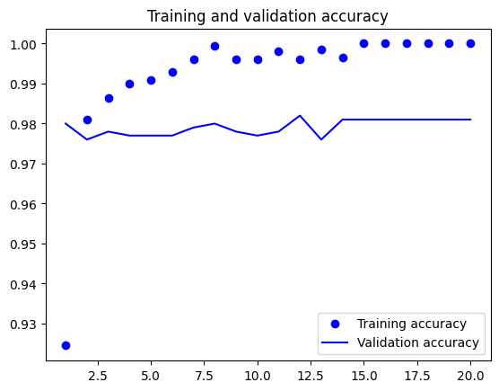

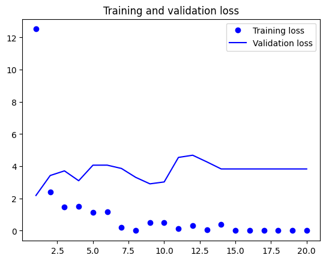

```python
import matplotlib.pyplot as plt
accuracy6 = hist6.history["accuracy"]
valaccuracy6 = hist6.history["val_accuracy"]
los6 = hist6.history["loss"]
vallos6 = hist6.history["val_loss"]
epochs = range(1, len(accuracy6) + 1)
plt.plot(epochs, accuracy6, "bo", label="Training accuracy")
plt.plot(epochs, valaccuracy6, "b", label="Validation accuracy")
plt.title("Training and validation accuracy")
plt.legend()
plt.figure()
plt.plot(epochs, los6, "bo", label="Training loss")
plt.plot(epochs, vallos6, "b", label="Validation loss")
plt.title("Training and validation loss")
plt.legend()
plt.show()
```

VGG16 convolutional base instantiation and freezing

```python
convolution_base  = keras.applications.vgg16.VGG16(
    weights="imagenet",
    include_top=False)
convolution_base.trainable = False

convolution_base.trainable = True
print("This is the number of trainable weights "
      "before freezing the conv base:", len(convolution_base.trainable_weights))

convolution_base.trainable = False
print("This is the number of trainable weights "
      "after freezing the conv base:", len(convolution_base.trainable_weights))
```

```
This is the number of trainable weights before freezing the conv base: 26
This is the number of trainable weights after freezing the conv base: 0
```

Model is now performing with a classifier and agumentation to convulation base

```python
augmentation2 = keras.Sequential(
    [
        layers.RandomFlip("horizontal"),
        layers.RandomRotation(0.1),
        layers.RandomZoom(0.2),
    ]
)

input22 = keras.Input(shape=(180, 180, 3))
x1 = augmentation2(input22)
x1 =keras.layers.Lambda(
     lambda x: keras.applications.vgg16.preprocess_input(x))(x1)
x1 = convolution_base(x1)
x1 = layers.Flatten()(x1)
x1 = layers.Dense(256)(x1)
x1 = layers.Dropout(0.5)(x1)
outputs = layers.Dense(1, activation="sigmoid")(x1)
model = keras.Model(input22, outputs)
model.compile(loss="binary_crossentropy",
              optimizer="rmsprop",
              metrics=["accuracy"])
```

```python
callbacks = [
    keras.callbacks.ModelCheckpoint(
        filepath="features_extraction_with_augmentation2.keras",
        save_best_only=True,
        monitor="val_loss"
    )
]

history = model.fit(
    train,
    epochs=10,
    validation_data=validation,
    callbacks=callbacks
)
```

```
63/63 ━━━━━━━━━━━━━━━━━━━━ 19s 232ms/step - accuracy: 0.8146 - loss: 55.7647 - val_accuracy: 0.9520 - val_loss: 7.6698
63/63 ━━━━━━━━━━━━━━━━━━━━ 11s 181ms/step - accuracy: 0.9329 - loss: 10.2929 - val_accuracy: 0.9760 - val_loss: 3.3231
63/63 ━━━━━━━━━━━━━━━━━━━━ 20s 165ms/step - accuracy: 0.9462 - loss: 8.2769 - val_accuracy: 0.9740 - val_loss: 4.9731
63/63 ━━━━━━━━━━━━━━━━━━━━ 10s 165ms/step - accuracy: 0.9612 - loss: 5.4164 - val_accuracy: 0.9720 - val_loss: 4.3382
63/63 ━━━━━━━━━━━━━━━━━━━━ 21s 166ms/step - accuracy: 0.9586 - loss: 6.1609 - val_accuracy: 0.9740 - val_loss: 3.6984
63/63 ━━━━━━━━━━━━━━━━━━━━ 13s 202ms/step - accuracy: 0.9632 - loss: 4.7946 - val_accuracy: 0.9790 - val_loss: 3.0918
63/63 ━━━━━━━━━━━━━━━━━━━━ 11s 167ms/step - accuracy: 0.9781 - loss: 2.6263 - val_accuracy: 0.9790 - val_loss: 3.6443
63/63 ━━━━━━━━━━━━━━━━━━━━ 22s 194ms/step - accuracy: 0.9655 - loss: 3.5320 - val_accuracy: 0.9730 - val_loss: 5.9696
63/63 ━━━━━━━━━━━━━━━━━━━━ 21s 204ms/step - accuracy: 0.9660 - loss: 3.7106 - val_accuracy: 0.9830 - val_loss: 2.5748
63/63 ━━━━━━━━━━━━━━━━━━━━ 12s 195ms/step - accuracy: 0.9711 - loss: 3.3978 - val_accuracy: 0.9700 - val_loss: 4.9607
```

```python
!ls -lh features_extraction_with_augmentation2.keras
```

```
-rw-r--r-- 1 root root 82M Oct 20 23:50 features_extraction_with_augmentation2.keras
```

```python
from tensorflow import keras
from tensorflow.keras import layers
from tensorflow.keras.applications import vgg16

# Define the model
augmentation2 = keras.Sequential(
    [
        layers.RandomFlip("horizontal"),
        layers.RandomRotation(0.1),
        layers.RandomZoom(0.2),
    ]
)

input22 = keras.Input(shape=(180, 180, 3))

x1 = augmentation2(input22)

# Specify output_shape for Lambda layer
x1 = keras.layers.Lambda(
    lambda x: vgg16.preprocess_input(x),
    output_shape=(180, 180, 3)
)(x1)

x1 = convolution_base(x1)
x1 = layers.Flatten()(x1)
x1 = layers.Dense(256)(x1)
x1 = layers.Dropout(0.5)(x1)
outputs = layers.Dense(1, activation="sigmoid")(x1)

model = keras.Model(input22, outputs)
model.compile(loss="binary_crossentropy",
              optimizer="rmsprop",
              metrics=["accuracy"])

# Save the model
callbacks = [
    keras.callbacks.ModelCheckpoint(
        filepath="features_extraction_with_augmentation2.keras",
        save_best_only=True,
        monitor="val_loss"
    )
]

history = model.fit(
    train,
    epochs=10,
    validation_data=validation,
    callbacks=callbacks
)
```

```
63/63 ━━━━━━━━━━━━━━━━━━━━ 13s 180ms/step - accuracy: 0.8425 - loss: 33.5289 - val_accuracy: 0.9470 - val_loss: 7.6318
63/63 ━━━━━━━━━━━━━━━━━━━━ 20s 174ms/step - accuracy: 0.9311 - loss: 8.0192 - val_accuracy: 0.9710 - val_loss: 3.2231
63/63 ━━━━━━━━━━━━━━━━━━━━ 21s 179ms/step - accuracy: 0.9476 - loss: 7.8120 - val_accuracy: 0.9800 - val_loss: 2.5410
63/63 ━━━━━━━━━━━━━━━━━━━━ 20s 167ms/step - accuracy: 0.9574 - loss: 5.9369 - val_accuracy: 0.9800 - val_loss: 3.2029
63/63 ━━━━━━━━━━━━━━━━━━━━ 20s 165ms/step - accuracy: 0.9635 - loss: 4.6270 - val_accuracy: 0.9770 - val_loss: 2.5707
63/63 ━━━━━━━━━━━━━━━━━━━━ 21s 167ms/step - accuracy: 0.9739 - loss: 3.3650 - val_accuracy: 0.9800 - val_loss: 3.1241
63/63 ━━━━━━━━━━━━━━━━━━━━ 20s 166ms/step - accuracy: 0.9546 - loss: 5.8260 - val_accuracy: 0.9790 - val_loss: 2.9116
63/63 ━━━━━━━━━━━━━━━━━━━━ 22s 193ms/step - accuracy: 0.9753 - loss: 2.2139 - val_accuracy: 0.9820 - val_loss: 2.9244
63/63 ━━━━━━━━━━━━━━━━━━━━ 21s 195ms/step - accuracy: 0.9776 - loss: 2.0536 - val_accuracy: 0.9440 - val_loss: 11.4675
63/63 ━━━━━━━━━━━━━━━━━━━━ 21s 206ms/step - accuracy: 0.9731 - loss: 3.2508 - val_accuracy: 0.9820 - val_loss: 2.4256
```

Fine-tuning a pretrained model

Freezing all layers until the fourth from the last

```python
convolution_base.trainable = True
for layer in convolution_base.layers[:-4]:
    layer.trainable = False
```

```python
model.compile(loss="binary_crossentropy",
              optimizer=keras.optimizers.RMSprop(learning_rate=1e-5),
              metrics=["accuracy"])

callbackstu = [
    keras.callbacks.ModelCheckpoint(
        filepath="fine_tuning.keras",
        save_best_only=True,
        monitor="val_loss")
]
historytune = model.fit(
    train,
    epochs=30,
    validation_data=validation,
    callbacks=callbackstu)
```

```
63/63 ━━━━━━━━━━━━━━━━━━━━ 16s 202ms/step - accuracy: 0.9750 - loss: 2.2357 - val_accuracy: 0.9840 - val_loss: 1.7389
63/63 ━━━━━━━━━━━━━━━━━━━━ 22s 224ms/step - accuracy: 0.9716 - loss: 1.9842 - val_accuracy: 0.9830 - val_loss: 1.4612
63/63 ━━━━━━━━━━━━━━━━━━━━ 18s 184ms/step - accuracy: 0.9847 - loss: 1.0297 - val_accuracy: 0.9820 - val_loss: 1.5035
63/63 ━━━━━━━━━━━━━━━━━━━━ 20s 181ms/step - accuracy: 0.9888 - loss: 0.9753 - val_accuracy: 0.9780 - val_loss: 2.2173
63/63 ━━━━━━━━━━━━━━━━━━━━ 13s 208ms/step - accuracy: 0.9835 - loss: 0.9381 - val_accuracy: 0.9830 - val_loss: 1.6107
63/63 ━━━━━━━━━━━━━━━━━━━━ 11s 181ms/step - accuracy: 0.9897 - loss: 0.4354 - val_accuracy: 0.9820 - val_loss: 1.4922
63/63 ━━━━━━━━━━━━━━━━━━━━ 22s 211ms/step - accuracy: 0.9870 - loss: 0.9007 - val_accuracy: 0.9840 - val_loss: 1.9148
63/63 ━━━━━━━━━━━━━━━━━━━━ 19s 193ms/step - accuracy: 0.9841 - loss: 0.6117 - val_accuracy: 0.9860 - val_loss: 1.4089
63/63 ━━━━━━━━━━━━━━━━━━━━ 20s 183ms/step - accuracy: 0.9831 - loss: 0.7613 - val_accuracy: 0.9780 - val_loss: 2.0531
63/63 ━━━━━━━━━━━━━━━━━━━━ 12s 198ms/step - accuracy: 0.9862 - loss: 0.9772 - val_accuracy: 0.9820 - val_loss: 1.3373
63/63 ━━━━━━━━━━━━━━━━━━━━ 19s 182ms/step - accuracy: 0.9893 - loss: 0.4256 - val_accuracy: 0.9770 - val_loss: 1.6627
63/63 ━━━━━━━━━━━━━━━━━━━━ 23s 221ms/step - accuracy: 0.9938 - loss: 0.1546 - val_accuracy: 0.9810 - val_loss: 1.1902
63/63 ━━━━━━━━━━━━━━━━━━━━ 20s 220ms/step - accuracy: 0.9904 - loss: 0.3779 - val_accuracy: 0.9840 - val_loss: 1.0580
63/63 ━━━━━━━━━━━━━━━━━━━━ 13s 211ms/step - accuracy: 0.9928 - loss: 0.2287 - val_accuracy: 0.9820 - val_loss: 1.2403
63/63 ━━━━━━━━━━━━━━━━━━━━ 19s 184ms/step - accuracy: 0.9856 - loss: 0.6195 - val_accuracy: 0.9780 - val_loss: 1.6966
63/63 ━━━━━━━━━━━━━━━━━━━━ 13s 209ms/step - accuracy: 0.9873 - loss: 0.4070 - val_accuracy: 0.9820 - val_loss: 1.4689
63/63 ━━━━━━━━━━━━━━━━━━━━ 21s 211ms/step - accuracy: 0.9945 - loss: 0.1506 - val_accuracy: 0.9840 - val_loss: 1.4097
63/63 ━━━━━━━━━━━━━━━━━━━━ 19s 181ms/step - accuracy: 0.9938 - loss: 0.1191 - val_accuracy: 0.9840 - val_loss: 1.4420
63/63 ━━━━━━━━━━━━━━━━━━━━ 21s 186ms/step - accuracy: 0.9936 - loss: 0.3306 - val_accuracy: 0.9830 - val_loss: 1.1657
63/63 ━━━━━━━━━━━━━━━━━━━━ 22s 211ms/step - accuracy: 0.9917 - loss: 0.1476 - val_accuracy: 0.9840 - val_loss: 1.3665
63/63 ━━━━━━━━━━━━━━━━━━━━ 19s 181ms/step - accuracy: 0.9964 - loss: 0.0362 - val_accuracy: 0.9820 - val_loss: 1.5327
63/63 ━━━━━━━━━━━━━━━━━━━━ 21s 185ms/step - accuracy: 0.9939 - loss: 0.1869 - val_accuracy: 0.9820 - val_loss: 1.6831
63/63 ━━━━━━━━━━━━━━━━━━━━ 20s 180ms/step - accuracy: 0.9909 - loss: 0.2030 - val_accuracy: 0.9810 - val_loss: 1.4956
63/63 ━━━━━━━━━━━━━━━━━━━━ 21s 184ms/step - accuracy: 0.9935 - loss: 0.1381 - val_accuracy: 0.9820 - val_loss: 1.3876
63/63 ━━━━━━━━━━━━━━━━━━━━ 20s 182ms/step - accuracy: 0.9912 - loss: 0.2819 - val_accuracy: 0.9800 - val_loss: 1.4787
63/63 ━━━━━━━━━━━━━━━━━━━━ 21s 183ms/step - accuracy: 0.9889 - loss: 0.2334 - val_accuracy: 0.9830 - val_loss: 1.3827
63/63 ━━━━━━━━━━━━━━━━━━━━ 21s 184ms/step - accuracy: 0.9913 - loss: 0.2662 - val_accuracy: 0.9800 - val_loss: 1.2203
63/63 ━━━━━━━━━━━━━━━━━━━━ 21s 197ms/step - accuracy: 0.9976 - loss: 0.0909 - val_accuracy: 0.9820 - val_loss: 0.9762
63/63 ━━━━━━━━━━━━━━━━━━━━ 20s 183ms/step - accuracy: 0.9935 - loss: 0.2967 - val_accuracy: 0.9840 - val_loss: 1.0875
63/63 ━━━━━━━━━━━━━━━━━━━━ 20s 182ms/step - accuracy: 0.9937 - loss: 0.1499 - val_accuracy: 0.9840 - val_loss: 1.0247
```

```python
model_tuning = keras.models.load_model("fine_tuning.keras",safe_mode=False)
test_loss, test_acc = model.evaluate(test)
print(f"Test accuracy: {test_acc:.3f}")
```

```
32/32 ━━━━━━━━━━━━━━━━━━━━ 3s 106ms/step - accuracy: 0.9790 - loss: 2.9140
Test accuracy: 0.970
```